# Constant Proportion Portfolio Insurance (CPPI)

- Run a Constant Proportion Portfolio Insurance (CPPI) strategy
- Explore how adjusting CPPI parameters affects floor violations

```python
import numpy as np
import pandas as pd
import edhec_risk_kit as erk
import matplotlib.pyplot as plt
%matplotlib inline
```

### Run a Constant Proportion Portfolio Insurance (CPPI) strategy:

- Keep exposure in a risky asset for upside potential, while ensuring capital preservation by increasing allocation to a safe asset if your portfolio value is nearing a set floor.

[figure not shown]

```python
ind_return = erk.get_ind_returns()

# simulate returns from a safer asset, like bonds,
# using geometric brownian motion
safe_r = erk.gbm(
    n_years=10,
    n_scenarios=1,
    mu=0.03,
    sigma=0.015
).pct_change().dropna()

# retrieve telecom returns from 2005 to 2014
# some processing so it runs properly in run_cppi()
risky_r = ind_return.loc['2005':'2014', 'Telcm'].reset_index().drop('index', axis=1)
risky_r.columns = [0]

# CPPI with monthly rebalances
# m = cushion multiplier
backtest = erk.run_cppi(
    risky_r=risky_r,
    safe_r=safe_r,
    m=2,
    start=1000,
    floor=0.7,
)
```

### Plot performance of CPPI strategy (black) vs strategy of allocating 100% of portfolio to the risky asset (orange)

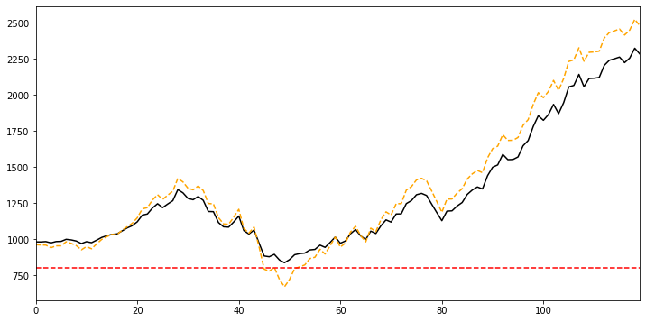

```python
fig, ax = plt.subplots(figsize=(12,6))
backtest['Wealth'].plot(ax=ax, color='k', legend=False)
backtest['Risky Wealth'].plot(ax=ax, color='orange', style='--', legend=False)
ax.axhline(1000*0.8, color='red', linestyle='--')
plt.show()
```

### Explore how adjusting CPPI parameters affects floor violations

How does increasing the cusion multiplier m from 2 to 3 affect floor violations? Notice in the above example, there were no floor violations in the above case with m=2

```python
# CPPI with monthly rebalances
# m = cushion multiplier
backtest = erk.run_cppi(
    risky_r=risky_r,
    safe_r=safe_r,
    m=3,
    start=1000,
    floor=0.7,
)
```

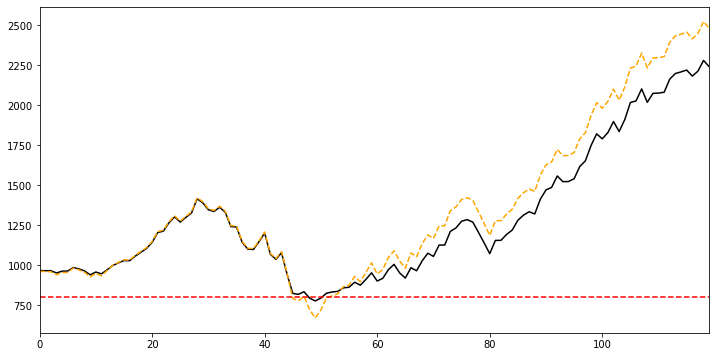

```python
fig, ax = plt.subplots(figsize=(12,6))
backtest['Wealth'].plot(ax=ax, color='k', legend=False)
backtest['Risky Wealth'].plot(ax=ax, color='orange', style='--', legend=False)
ax.axhline(1000*0.8, color='red', linestyle='--')
plt.show()
```

```python
backtest['Wealth'].min()
```

```
0    775.414598
dtype: float64
```

#### Utilize a max drawdown constraint to create a moving floor. Set the floor value to 70% of max(peak, account_value)

```python
# with m=3, floor value being 70% of max(peak, account_value),
# max allocation to risky assket is 3*(100-70) = 90%
backtest = erk.run_cppi(
    risky_r=risky_r,
    safe_r=safe_r,
    m=3,
    start=1000,
    riskfree_rate=0.02,
    drawdown=0.3
)
```

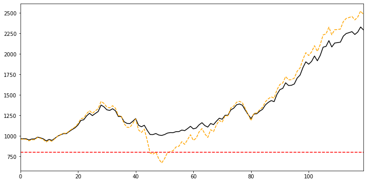

```python
fig, ax = plt.subplots(figsize=(12,6))
backtest['Wealth'].plot(ax=ax, color='k', legend=False)
backtest['Risky Wealth'].plot(ax=ax, color='orange', style='--', legend=False)
ax.axhline(1000*0.8, color='red', linestyle='--')
plt.show()
```

### Summary of CPPI's returns

```python
erk.summary_stats(backtest['Wealth'].pct_change().dropna())
```

|  | Annualized Return | Annualized Vol | Skewness | Kurtosis | Cornish-Fisher VaR (5%) | Historic CVaR (5%) | Sharpe Ratio | Max Drawdown |
| --- | --- | --- | --- | --- | --- | --- | --- | --- |
| 0 | 0.091101 | 0.091534 | -0.431639 | 2.932767 | 0.038814 | 0.053166 | 0.649604 | -0.269928 |

### Summary of 100% Telecom returns

```python
erk.summary_stats(backtest['Risky Wealth'].pct_change().dropna())
```

|  | Annualized Return | Annualized Vol | Skewness | Kurtosis | Cornish-Fisher VaR (5%) | Historic CVaR (5%) | Sharpe Ratio | Max Drawdown |
| --- | --- | --- | --- | --- | --- | --- | --- | --- |
| 0 | 0.100365 | 0.156669 | -0.879384 | 4.569815 | 0.074217 | 0.108783 | 0.436942 | -0.529317 |

### CPPI strategy provided much better risk protection

- Max drawdown was halved,
- Negative skewness reduced,
- VaR and CVar near halved
- Higher Sharpe ratio
- Much less fat tail on distribution of monthly returns (kurtosis)